# **LINKED LIST**

## Pengertian Linked List

Linked List adalah struktur data linear yang digunakan untuk menyimpan sekumpulan data secara berurutan menggunakan hubungan antar node. Linked List termasuk salah satu struktur data dasar yang sangat penting dalam dunia pemrograman dan algoritma.

Berbeda dengan array yang menyimpan data secara bersebelahan di memori komputer, Linked List menyimpan data dalam node-node yang saling terhubung menggunakan pointer atau reference.

Karena menggunakan hubungan antar node, Linked List memiliki sifat:

- dinamis,
- fleksibel,
- mudah ditambah,
- dan mudah dikurangi.

Ukuran Linked List dapat berubah saat program berjalan tanpa harus menentukan ukuran awal seperti pada array.

Linked List banyak digunakan pada:

- sistem operasi,
- browser,
- database,
- aplikasi editor,
- playlist musik,
- manajemen memori,
- graph,
- queue,
- stack,
- dan berbagai sistem komputer modern lainnya.

# Konsep Dasar Linked List

Linked List terdiri dari kumpulan node.

Setiap node memiliki minimal dua bagian:

1. data,
2. pointer/reference.

# Struktur Node

Ilustrasi node:

```
[ DATA | NEXT ]
```

Keterangan:

- DATA → menyimpan nilai/data
- NEXT → menyimpan alamat node berikutnya

# Contoh Node

```
[10 | alamat node berikutnya]
```

Node pertama terhubung ke node kedua, node kedua ke node ketiga, dan seterusnya.

# Ilustrasi Linked List

```
10 -> 20 -> 30 -> None
```

Penjelasan:

- node pertama menyimpan angka 10,
- node kedua menyimpan angka 20,
- node ketiga menyimpan angka 30,
- node terakhir menunjuk ke None.

None berarti:

- tidak ada node berikutnya,
- atau akhir dari Linked List.

# Cara Kerja Linked List

Linked List bekerja menggunakan hubungan antar node melalui pointer.

Langkah kerja:

1. node dibuat,
2. node menyimpan data,
3. pointer menghubungkan node satu ke node lain,
4. proses berlanjut sampai node terakhir.

Setiap node mengetahui:

- siapa node berikutnya.

Namun pada Singly Linked List:

- node tidak mengetahui node sebelumnya.

# Perbedaan Linked List dan Array

Banyak mahasiswa sering bingung membedakan array dan Linked List.

# Array

Pada array:

- data disimpan berurutan di memori.

Contoh:

```
[10][20][30][40]
```

Keuntungan:

- akses index sangat cepat.

Kekurangan:

- ukuran sulit diubah.

# Linked List

Pada Linked List:

- data tidak harus bersebelahan di memori.

Contoh:

```
10 -> 20 -> 30 -> 40
```

Keuntungan:

- ukuran fleksibel,
- insertion dan deletion lebih mudah.

Kekurangan:

- akses data lebih lambat.

# Mengapa Linked List Dibutuhkan?

Array memiliki beberapa kelemahan:

1. ukuran tetap,
2. sulit insertion di tengah,
3. sulit deletion,
4. membutuhkan perpindahan data.

Linked List dibuat untuk mengatasi masalah tersebut.

Dengan Linked List:

- penambahan data lebih fleksibel,
- penghapusan data lebih mudah,
- tidak perlu menggeser seluruh data.

# Komponen Utama Linked List

# 1. Node

Node adalah elemen utama penyimpan data.

Node terdiri dari:

- data,
- dan pointer.

Contoh:

```
Node:
data = 15
next = alamat node berikutnya
```

# 2. Head

Head adalah node pertama dalam Linked List.

Contoh:

```
Head -> 10 -> 20 -> 30
```

Head menunjuk ke node pertama.

Jika Linked List kosong:

```
Head = None
```

# 3. Tail

Tail adalah node terakhir.

Biasanya node terakhir memiliki:

```
next = None
```

# 4. Pointer / Reference

Pointer digunakan untuk:

- menghubungkan node.

Tanpa pointer:

- node tidak dapat saling terhubung.

# Jenis-Jenis Linked List

Linked List memiliki beberapa jenis penting.

# 1. Singly Linked List

## Pengertian

Singly Linked List adalah Linked List yang setiap node hanya memiliki satu pointer menuju node berikutnya.

Ilustrasi:

```
10 -> 20 -> 30 -> None
```

Karakteristik:

- hanya bisa berjalan satu arah,
- lebih sederhana,
- memori lebih kecil.

# 2. Doubly Linked List

## Pengertian

Doubly Linked List memiliki dua pointer:

1. pointer next,
2. pointer previous.

Ilustrasi:

```
None <- 10 <-> 20 <-> 30 -> None
```

Karakteristik:

- bisa traversal maju dan mundur,
- lebih fleksibel,
- membutuhkan memori lebih besar.

# 3. Circular Linked List

## Pengertian

Circular Linked List adalah Linked List dimana node terakhir kembali menunjuk ke node pertama.

Ilustrasi:

```
10 -> 20 -> 30
^           |
|___________|
```

Karakteristik:

- tidak memiliki None,
- membentuk lingkaran.

# Operasi Dasar Linked List

Dalam Linked List terdapat beberapa operasi penting.

# 1. Traversal

## Pengertian

Traversal adalah proses menelusuri seluruh node dari awal hingga akhir.

Contoh:

```
10 -> 20 -> 30 -> None
```

Urutan traversal:

1. 10
2. 20
3. 30

Traversal dilakukan menggunakan pointer current.

# 2. Insertion

## Pengertian

Insertion adalah proses menambahkan node baru.

# Jenis Insertion

## a. Insertion di Awal

Contoh:

Sebelum:

```
20 -> 30
```

Tambah 10:

```
10 -> 20 -> 30
```

## b. Insertion di Tengah

Contoh:

```
10 -> 30
```

Tambah 20:

```
10 -> 20 -> 30
```

## c. Insertion di Akhir

Contoh:

```
10 -> 20
```

Tambah 30:

```
10 -> 20 -> 30
```

# 3. Deletion

## Pengertian

Deletion adalah proses menghapus node.

# Jenis Deletion

## a. Hapus Awal

```
10 -> 20 -> 30
```

Menjadi:

```
20 -> 30
```

## b. Hapus Tengah

```
10 -> 20 -> 30
```

Hapus 20:

```
10 -> 30
```

## c. Hapus Akhir

```
10 -> 20 -> 30
```

Menjadi:

```
10 -> 20
```

# 4. Searching

## Pengertian

Searching adalah proses mencari data tertentu.

Karena Linked List tidak memiliki index:

- pencarian dilakukan satu per satu.

# Cara Searching

Contoh:

```
10 -> 20 -> 30
```

Cari 30:

1. cek 10
2. cek 20
3. cek 30 ditemukan

# Cara Kerja Pointer Pada Linked List

Pointer sangat penting dalam Linked List.

Contoh:

```
10 -> 20 -> 30
```

Node 10 menyimpan alamat node 20.

Node 20 menyimpan alamat node 30.

Node 30 menyimpan:

```
None
```

# 1. Ukuran Dinamis

Data dapat bertambah kapan saja.

# 2. Mudah Insertion dan Deletion

Tidak perlu menggeser seluruh data.

# 3. Efisien Untuk Data Dinamis

Cocok untuk data yang sering berubah.

# 4. Fleksibel

Dapat dikembangkan menjadi:

- stack,
- queue,
- graph,
- tree.

# 1. Akses Data Lambat

Karena traversal satu per satu.

Kompleksitas:

O(n)

# 2. Membutuhkan Memori Tambahan

Untuk pointer.

# 3. Tidak Mendukung Random Access

Tidak bisa langsung:

```
data[5]
```

seperti array.

# 4. Implementasi Lebih Sulit

Dibanding array biasa.

# Kompleksitas Waktu Linked List

| Operasi | Kompleksitas |
| --- | --- |
| Traversal | O(n) |
| Searching | O(n) |
| Insertion Awal | O(1) |
| Deletion Awal | O(1) |

# Penerapan Linked List Dalam Dunia Nyata

# 1. Browser History

Saat menekan:

- back,
- forward,

browser menggunakan konsep Linked List.

Contoh browser:

- Google Chrome
- Mozilla Firefox

# 2. Playlist Musik

Lagu saling terhubung satu sama lain.

# 3. Undo dan Redo

Editor teks menggunakan Linked List untuk menyimpan riwayat perubahan.

# 4. Sistem Kereta

Gerbong kereta saling terhubung seperti node.

# 5. Manajemen Memori

Sistem operasi menggunakan Linked List untuk mengatur memori.

# Contoh Program Singly Linked List Python

```
class Node:

    def __init__(self, data):

        self.data = data
        self.next = None


class LinkedList:

    def __init__(self):

        self.head = None

    def tambah_di_akhir(self, data):

        node_baru = Node(data)

        if self.head is None:

            self.head = node_baru

        else:

            current = self.head

            while current.next:

                current = current.next

            current.next = node_baru

    def tampilkan(self):

        current = self.head

        while current:

            print(current.data, end=" -> ")

            current = current.next

        print("None")


ll = LinkedList()

ll.tambah_di_akhir(10)
ll.tambah_di_akhir(20)
ll.tambah_di_akhir(30)

ll.tampilkan()
```

# Penjelasan Program

## 1. Class Node

```
self.data
self.next
```

Digunakan untuk menyimpan data dan pointer.

## 2. Head

```
self.head = None
```

Menandakan Linked List awalnya kosong.

## 3. Menambahkan Node

```
current.next = node_baru
```

Menghubungkan node lama dengan node baru.

## 4. Traversal

```
while current:
```

Menampilkan seluruh node.

# Output Program

```
10 -> 20 -> 30 -> None
```

# Kesimpulan

Linked List adalah struktur data linear dinamis yang menyimpan data menggunakan node-node yang saling terhubung melalui pointer.

Linked List sangat penting karena:

- fleksibel,
- mudah melakukan insertion dan deletion,
- cocok untuk data dinamis,
- dan digunakan dalam berbagai sistem komputer modern.

Meskipun akses data lebih lambat dibanding array, Linked List tetap menjadi salah satu struktur data fundamental yang wajib dipahami dalam Struktur Data dan Algoritma.

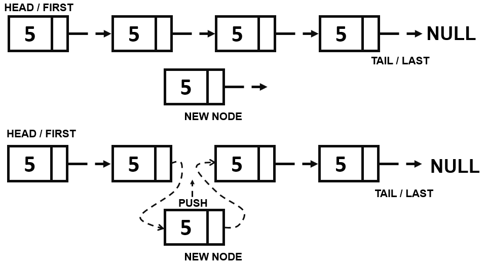

### **Contoh Code:**

```python
class Node:

    def __init__(self, data):
        self.data = data
        self.next = None


node1 = Node(10)
node2 = Node(20)

node1.next = node2

print(node1.data)
print(node1.next.data)
```

```
10
20
```

```python
class Node:

    def __init__(self, data):
        self.data = data
        self.next = None

head = Node(10)

node2 = Node(20)
node3 = Node(30)

head.next = node2
node2.next = node3

current = head

while current is not None:
    print(current.data)
    current = current.next
```

```
10
20
30
```

```python
class Node:

    def __init__(self, data):
        self.data = data
        self.next = None

class LinkedList:

    def __init__(self):
        self.head = None

    def tambah_akhir(self, data):
        new_node = Node(data)

        if self.head is None:
            self.head = new_node
            return
        current = self.head

        while current.next:
            current = current.next
        current.next = new_node

    def tampilkan(self):
        current = self.head

        while current:
            print(current.data)
            current = current.next

ll = LinkedList()
ll.tambah_akhir(10)
ll.tambah_akhir(20)
ll.tambah_akhir(30)
ll.tampilkan()
```

```
10
20
30
```

```python
class Node:
    def __init__(self, data):
        self.data = data
        self.next = None

    def getData(self):
        return self.data

    def getNext(self):
        return self.next

    def setNext(self, new_next):
        self.next = new_next


class LinkedList:
    def __init__(self):
        self.head = None

    def isEmpty(self):
        return self.head == None

    def addFront(self, item):
        temp = Node(item)
        temp.setNext(self.head)
        self.head = temp

    def addLast(self, item):
        temp = Node(item)

        if self.head == None:
            self.head = temp

        else:
            current = self.head

            while current.getNext() != None:
                current = current.getNext()

            current.setNext(temp)

    def __str__(self):
        current = self.head
        tmp = ""

        while current != None:
            tmp += str(current.getData()) + " "
            current = current.getNext()

        tmp = "[ " + tmp + "]"
        return tmp


dataList = LinkedList()

dataList.addFront(10)
dataList.addFront(4)
dataList.addFront(12)
dataList.addFront(3)
dataList.addFront(5)
print(dataList)

dataList.addLast(32)
dataList.addLast(7)
print(dataList)
```

```
[ 5 3 12 4 10 ]
[ 5 3 12 4 10 32 7 ]
```

```python
class Node:
  def __init__(self,val):
    self.val = val
    self.next = None
  def setNext(self,val):
    self.next = val
  def getData(self):
    return self.val

class LinkedList:
  def __init__(self,):
    self.head = None
  def setFront(self,val):
    a = Node(val)
    a.setNext(self.head)
    self.head = a
  def viewList(self):
    temp = self.head
    while temp != None:
      print(temp.getData())
      temp = temp.next
  def __str__(self):
    temp = self.head
    result = "["
    while temp != None:
      result += str(temp.getData())
      temp = temp.next
      if (temp):
        result += ","
    result += "]"
    return result

ls = LinkedList()
ls.setFront(10)
ls.setFront(20)
ls.setFront(30)

print(ls)
```

```
[30,20,10]
```